# General

| What | Result |
| --- | --- |
| Number of students | 349 |
| Number of questions | 26 |
| Average score | 10.189 |
| Standard deviation | 1.835 |
| Cronbach’s alpha | -0.16 |
| Standard error | 1.976 |

# Item statistics

For each question the frequency, percentage and item rest correlations (IRC) of every answer option are diplayed. The IRC should be (highly) positive for the right answer option and low for the wrong answer option(s).

- **Item 1**:

  | Answer Option | Frequency | Percentage | IRC | Correct |
  | --- | --- | --- | --- | --- |
  | **A** | **349** | **100** | **0** | **X** |
  | B | 0 | 0 | 0 |  |
  | C | 0 | 0 | 0 |  |
  | Missing | 0 | 0 | 0 |  |

- **Item 2**:

  | Answer Option | Frequency | Percentage | IRC | Correct |
  | --- | --- | --- | --- | --- |
  | **A** | **87** | **24.9** | **0.046** | **X** |
  | B | 215 | 61.6 | -0.037 |  |
  | C | 47 | 13.5 | -0.006 |  |
  | Missing | 0 | 0 | 0 |  |

- **Item 3**:

  | Answer Option | Frequency | Percentage | IRC | Correct |
  | --- | --- | --- | --- | --- |
  | A | 21 | 6 | 0.073 |  |
  | **B** | **177** | **50.7** | **-0.022** | **X** |
  | C | 151 | 43.3 | -0.013 |  |
  | Missing | 0 | 0 | 0 |  |

- **Item 4**:

  | Answer Option | Frequency | Percentage | IRC | Correct |
  | --- | --- | --- | --- | --- |
  | A | 79 | 22.6 | 0.012 |  |
  | B | 129 | 37 | -0.021 |  |
  | **C** | **141** | **40.4** | **0.011** | **X** |
  | Missing | 0 | 0 | 0 |  |

- **Item 5**:

  | Answer Option | Frequency | Percentage | IRC | Correct |
  | --- | --- | --- | --- | --- |
  | A | 251 | 71.9 | 0.084 |  |
  | **B** | **59** | **16.9** | **-0.064** | **X** |
  | C | 38 | 10.9 | -0.039 |  |
  | Missing | 0 | 0 | 0 |  |

- **Item 6**:

  | Answer Option | Frequency | Percentage | IRC | Correct |
  | --- | --- | --- | --- | --- |
  | **A** | **35** | **10** | **-0.042** | **X** |
  | B | 214 | 61.3 | 0.003 |  |
  | C | 100 | 28.7 | 0.025 |  |
  | Missing | 0 | 0 | 0 |  |

- **Item 7**:

  | Answer Option | Frequency | Percentage | IRC | Correct |
  | --- | --- | --- | --- | --- |
  | A | 16 | 4.6 | 0.019 |  |
  | **B** | **33** | **9.5** | **-0.054** | **X** |
  | C | 300 | 86 | 0.035 |  |
  | Missing | 0 | 0 | 0 |  |

- **Item 8**:

  | Answer Option | Frequency | Percentage | IRC | Correct |
  | --- | --- | --- | --- | --- |
  | A | 140 | 40.1 | -0.06 |  |
  | B | 111 | 31.8 | 0.036 |  |
  | **C** | **98** | **28.1** | **0.029** | **X** |
  | Missing | 0 | 0 | 0 |  |

- **Item 9**:

  | Answer Option | Frequency | Percentage | IRC | Correct |
  | --- | --- | --- | --- | --- |
  | A | 24 | 6.9 | 0.062 |  |
  | B | 276 | 79.1 | -0.061 |  |
  | **C** | **49** | **14** | **0.026** | **X** |
  | Missing | 0 | 0 | 0 |  |

- **Item 10**:

  | Answer Option | Frequency | Percentage | IRC | Correct |
  | --- | --- | --- | --- | --- |
  | A | 22 | 6.3 | 0.089 |  |
  | **B** | **319** | **91.4** | **-0.104** | **X** |
  | C | 8 | 2.3 | 0.05 |  |
  | Missing | 0 | 0 | 0 |  |

- **Item 11**:

  | Answer Option | Frequency | Percentage | IRC | Correct |
  | --- | --- | --- | --- | --- |
  | A | 34 | 9.7 | 0.068 |  |
  | **B** | **73** | **20.9** | **-0.03** | **X** |
  | C | 242 | 69.3 | -0.018 |  |
  | Missing | 0 | 0 | 0 |  |

- **Item 12**:

  | Answer Option | Frequency | Percentage | IRC | Correct |
  | --- | --- | --- | --- | --- |
  | A | 14 | 4 | -0.054 |  |
  | B | 185 | 53 | 0.088 |  |
  | **C** | **150** | **43** | **-0.067** | **X** |
  | Missing | 0 | 0 | 0 |  |

- **Item 13**:

  | Answer Option | Frequency | Percentage | IRC | Correct |
  | --- | --- | --- | --- | --- |
  | A | 244 | 69.9 | 0.06 |  |
  | B | 44 | 12.6 | 0.021 |  |
  | **C** | **61** | **17.5** | **-0.09** | **X** |
  | Missing | 0 | 0 | 0 |  |

- **Item 14**:

  | Answer Option | Frequency | Percentage | IRC | Correct |
  | --- | --- | --- | --- | --- |
  | **A** | **54** | **15.5** | **0.023** | **X** |
  | B | 245 | 70.2 | -0.008 |  |
  | C | 50 | 14.3 | -0.012 |  |
  | Missing | 0 | 0 | 0 |  |

- **Item 15**:

  | Answer Option | Frequency | Percentage | IRC | Correct |
  | --- | --- | --- | --- | --- |
  | A | 310 | 88.8 | -0.084 |  |
  | **B** | **27** | **7.7** | **0.072** | **X** |
  | C | 12 | 3.4 | 0.041 |  |
  | Missing | 0 | 0 | 0 |  |

- **Item 16**:

  | Answer Option | Frequency | Percentage | IRC | Correct |
  | --- | --- | --- | --- | --- |
  | **A** | **46** | **13.2** | **-0.008** | **X** |
  | B | 4 | 1.1 | -0.063 |  |
  | C | 299 | 85.7 | 0.027 |  |
  | Missing | 0 | 0 | 0 |  |

- **Item 17**:

  | Answer Option | Frequency | Percentage | IRC | Correct |
  | --- | --- | --- | --- | --- |
  | A | 22 | 6.3 | 0.029 |  |
  | B | 97 | 27.8 | 0.02 |  |
  | **C** | **230** | **65.9** | **-0.034** | **X** |
  | Missing | 0 | 0 | 0 |  |

- **Item 18**:

  | Answer Option | Frequency | Percentage | IRC | Correct |
  | --- | --- | --- | --- | --- |
  | A | 18 | 5.2 | 0.005 |  |
  | B | 20 | 5.7 | -0.089 |  |
  | **C** | **311** | **89.1** | **0.063** | **X** |
  | Missing | 0 | 0 | 0 |  |

- **Item 19**:

  | Answer Option | Frequency | Percentage | IRC | Correct |
  | --- | --- | --- | --- | --- |
  | A | 31 | 8.9 | 0.093 |  |
  | B | 16 | 4.6 | 0.006 |  |
  | **C** | **302** | **86.5** | **-0.082** | **X** |
  | Missing | 0 | 0 | 0 |  |

- **Item 20**:

  | Answer Option | Frequency | Percentage | IRC | Correct |
  | --- | --- | --- | --- | --- |
  | A | 307 | 88 | 0.107 |  |
  | B | 29 | 8.3 | -0.064 |  |
  | **C** | **13** | **3.7** | **-0.09** | **X** |
  | Missing | 0 | 0 | 0 |  |

- **Item 21**:

  | Answer Option | Frequency | Percentage | IRC | Correct |
  | --- | --- | --- | --- | --- |
  | **A** | **134** | **38.4** | **-0.081** | **X** |
  | B | 66 | 18.9 | 0.008 |  |
  | C | 148 | 42.4 | 0.073 |  |
  | Missing | 0 | 0 | 0 |  |

- **Item 22**:

  | Answer Option | Frequency | Percentage | IRC | Correct |
  | --- | --- | --- | --- | --- |
  | **A** | **152** | **43.6** | **-0.072** | **X** |
  | B | 98 | 28.1 | -0.014 |  |
  | C | 99 | 28.4 | 0.093 |  |
  | Missing | 0 | 0 | 0 |  |

- **Item 23**:

  | Answer Option | Frequency | Percentage | IRC | Correct |
  | --- | --- | --- | --- | --- |
  | **A** | **290** | **83.1** | **-0.033** | **X** |
  | B | 11 | 3.2 | 0.019 |  |
  | C | 48 | 13.8 | 0.027 |  |
  | Missing | 0 | 0 | 0 |  |

- **Item 24**:

  | Answer Option | Frequency | Percentage | IRC | Correct |
  | --- | --- | --- | --- | --- |
  | **A** | **240** | **68.8** | **-0.019** | **X** |
  | B | 88 | 25.2 | 0.003 |  |
  | C | 21 | 6 | 0.03 |  |
  | Missing | 0 | 0 | 0 |  |

- **Item 25**:

  | Answer Option | Frequency | Percentage | IRC | Correct |
  | --- | --- | --- | --- | --- |
  | **A** | **56** | **16** | **-0.071** | **X** |
  | B | 218 | 62.5 | 0.045 |  |
  | C | 75 | 21.5 | 0.011 |  |
  | Missing | 0 | 0 | 0 |  |

- **Item 26**:

  | Answer Option | Frequency | Percentage | IRC | Correct |
  | --- | --- | --- | --- | --- |
  | A | 33 | 9.5 | -0.014 |  |
  | **B** | **70** | **20.1** | **-0.048** | **X** |
  | C | 246 | 70.5 | 0.052 |  |
  | Missing | 0 | 0 | 0 |  |

## Percentage Correct

Plot of percentage correct per item. If *more than 70%* of the students answer an item correctly, the students have mastered the material well enough, thus it is coloured *green*. If *less than 40%* of the students answer an item correctly, the students have not mastered the material, and is coloured *red*. *Orange* indicates the percentage correct lies *between 40% and 70%*. The boundaries of the colours are based on multiple choice items with 3 or 4 answer options.

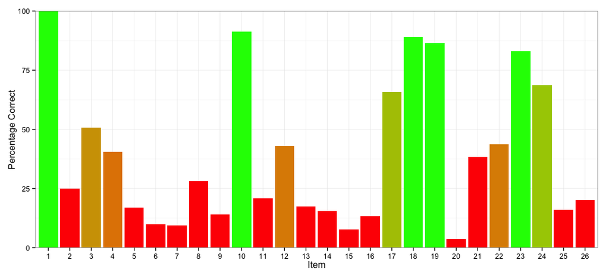

## Item rest correlations

Plot of Item Rest Correlations per item: The correlation between an item (0 for wrong answers and 1 for right answers) and the sum of all other items. Items with a correlation *higher than .05* indicate that students who answered this item correctly answered the other items more often correctly than students who answered this item incorrectly. Thus it is coloured *green*. Items with a correlation *lower than 0* indicate no relationship between this item and the other items, thus it is coloured *red*. *Between 0 and .05*, an item is coloured *orange*.

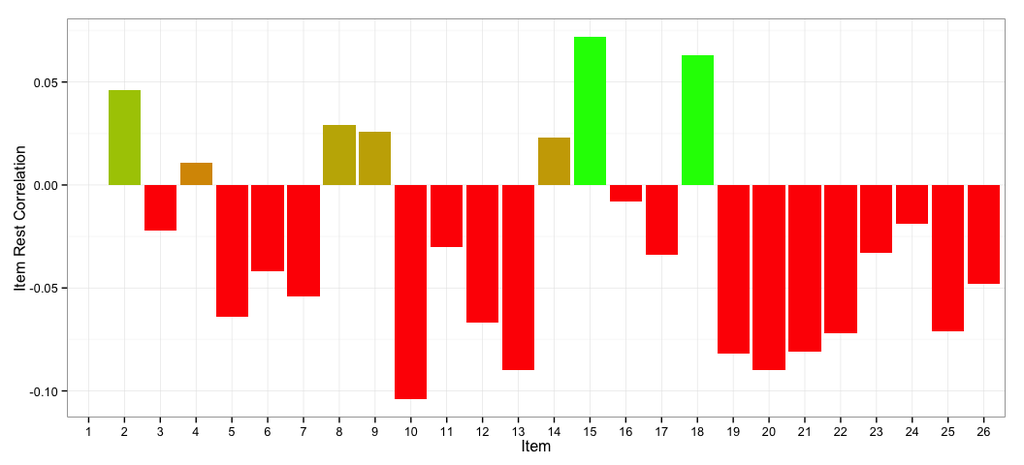

## Percentage chosen per answer options

Percentage plot of all answer options per question. **White** bars represent the **right** answer option(s) and **black** the **wrong** options.

The border represents the performance of an item. The **right** answer options are coloured *green* if *more than 70%* of the students choose this option. In that case, the students have mastered the material. They are coloured *red* if *less than 40%* choose this option. *Between 40% and 70%*, it is coloured *orange*.

The **wrong** answer options are coloured *green* if an option is chosen *10 percentage point less than the right option*. In that case, more students chose the right answer option than the wrong option indicating that students are not confused by the wrong option. They are coloured *red* if an option is chosen *equally or more often than the right option*. In this case, students pick the wrong answer option often, indicating that this option may be right as well. It is coloured *orange* in between these two.

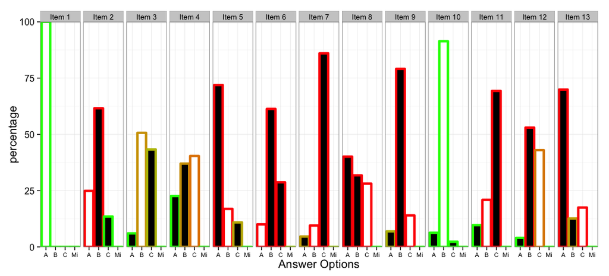

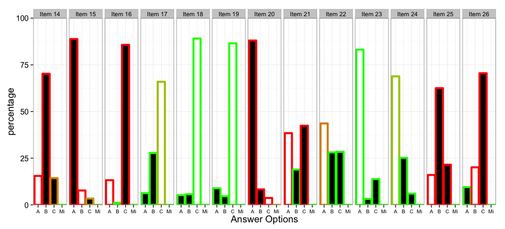

## Item rest correlations per answer option

Item rest correlation (IRC) plot of all answer options per question. The IRC is the correlation between an answer option (1 for students who chose this options and 0 for student who did not) and the sumscore on all other items. **White** bars represent the **right** answer option(s) and **black** the **wrong** options.

The border represents the performance of an item. The **right** answer options are coloured *green* if the IRC is *higher than .05*. In that case, students who picked the right answer option scored higher on all other items than student who did not pick the right option. They are coloured *red* if the IRC is *less than 0*. In that case, students who picked the right answer option scored equally or worse on the other items than students who picked the other options. Between *0 and .05*, the option is coloured *orange*.

The **wrong** answer options are coloured *green* if the IRC is *more than .1 lower than the right option*. In that case, students who answered the other items incorrectly, usually answered this item incorrectly as well. They are coloured *red* if the IRC is *equal or higher than the right answer option*. In that case, students who answered the other items correctly may have answered this item incorrectly. In between these two, the option is coloured *orange*.

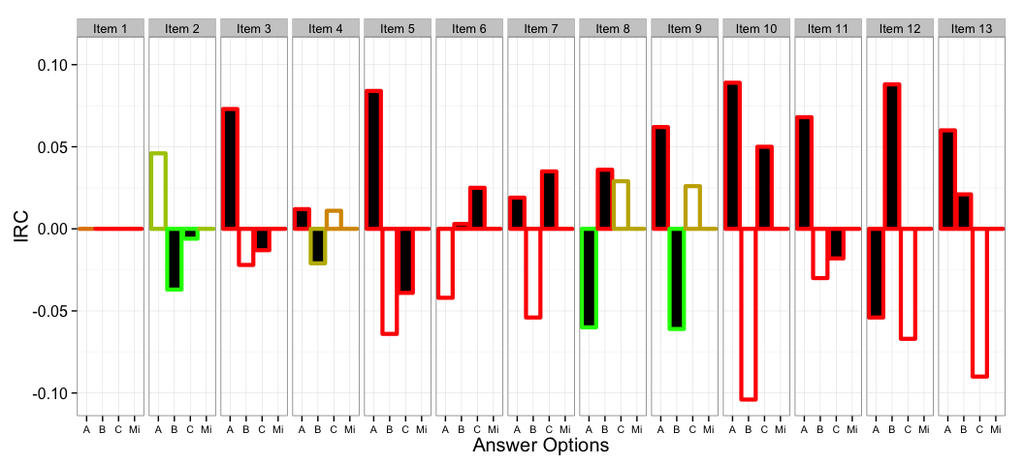

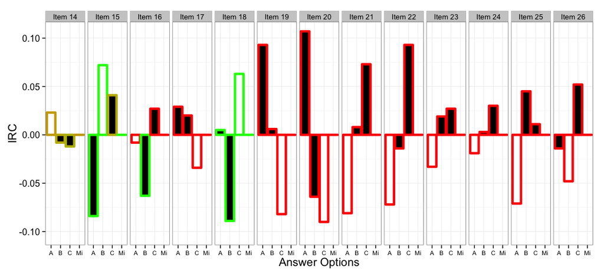

## Cumulative Distribution

Cumulative Distribution showing all possible scores and the percentage of students that scored that number or higher

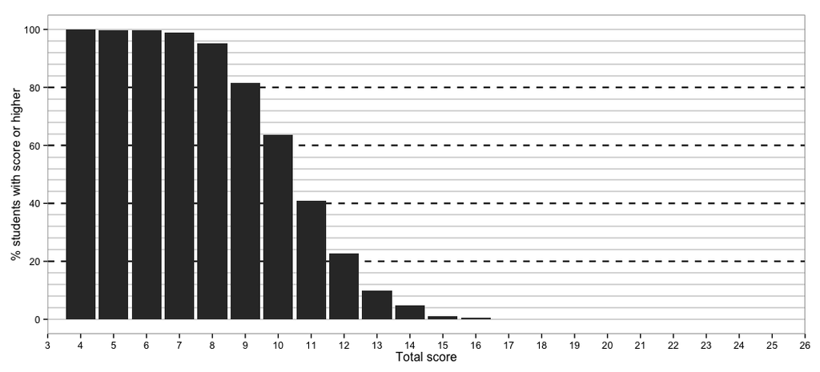

# Categories

#### Sub category analysis could not be performed for category 3 as this subcategory holds less than three items.

## Category 1

## Percentage Correct

Plot of percentage correct per item. If *more than 70%* of the students answer an item correctly, the students have mastered the material well enough, thus it is coloured *green*. If *less than 40%* of the students answer an item correctly, the students have not mastered the material, and is coloured *red*. *Orange* indicates the percentage correct lies *between 40% and 70%*. The boundaries of the colours are based on multiple choice items with 3 or 4 answer options.

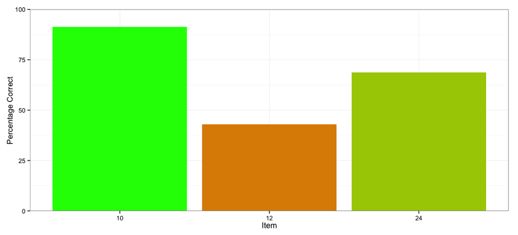

## Item rest correlations

Plot of Item Rest Correlations per item: The correlation between an item (0 for wrong answers and 1 for right answers) and the sum of all other items. Items with a correlation *higher than .05* indicate that students who answered this item correctly answered the other items more often correctly than students who answered this item incorrectly. Thus it is coloured *green*. Items with a correlation *lower than 0* indicate no relationship between this item and the other items, thus it is coloured *red*. *Between 0 and .05*, an item is coloured *orange*.

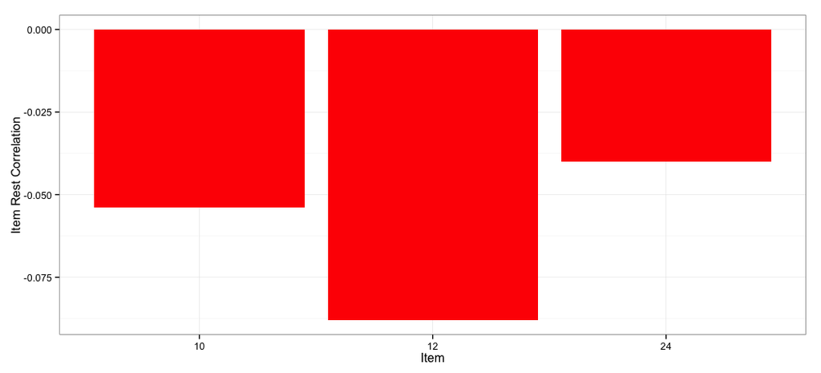

## Percentage chosen per answer options

Percentage plot of all answer options per question. **White** bars represent the **right** answer option(s) and **black** the **wrong** options.

The border represents the performance of an item. The **right** answer options are coloured *green* if *more than 70%* of the students choose this option. In that case, the students have mastered the material. They are coloured *red* if *less than 40%* choose this option. *Between 40% and 70%*, it is coloured *orange*.

The **wrong** answer options are coloured *green* if an option is chosen *10 percentage point less than the right option*. In that case, more students chose the right answer option than the wrong option indicating that students are not confused by the wrong option. They are coloured *red* if an option is chosen *equally or more often than the right option*. In this case, students pick the wrong answer option often, indicating that this option may be right as well. It is coloured *orange* in between these two.

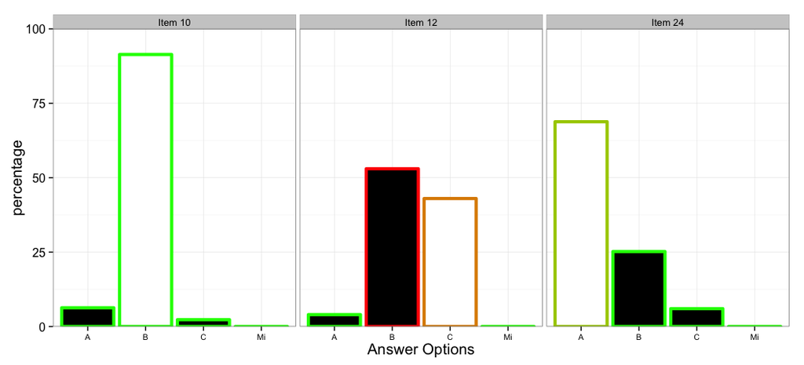

## Item rest correlations per answer option

Item rest correlation (IRC) plot of all answer options per question. The IRC is the correlation between an answer option (1 for students who chose this options and 0 for student who did not) and the sumscore on all other items. **White** bars represent the **right** answer option(s) and **black** the **wrong** options.

The border represents the performance of an item. The **right** answer options are coloured *green* if the IRC is *higher than .05*. In that case, students who picked the right answer option scored higher on all other items than student who did not pick the right option. They are coloured *red* if the IRC is *less than 0*. In that case, students who picked the right answer option scored equally or worse on the other items than students who picked the other options. Between *0 and .05*, the option is coloured *orange*.

The **wrong** answer options are coloured *green* if the IRC is *more than .1 lower than the right option*. In that case, students who answered the other items incorrectly, usually answered this item incorrectly as well. They are coloured *red* if the IRC is *equal or higher than the right answer option*. In that case, students who answered the other items correctly may have answered this item incorrectly. In between these two, the option is coloured *orange*.

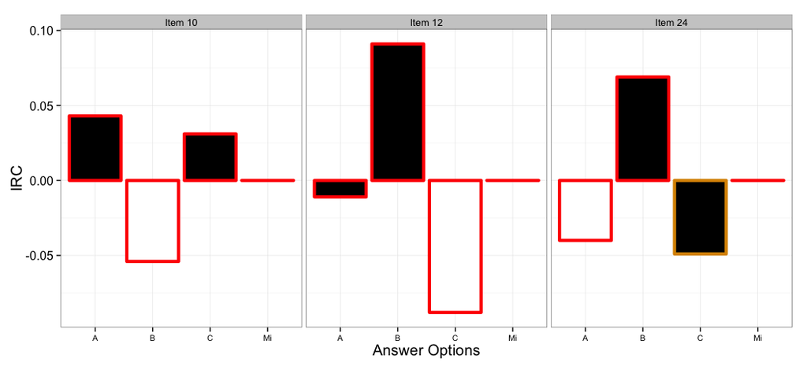

## Cumulative Distribution

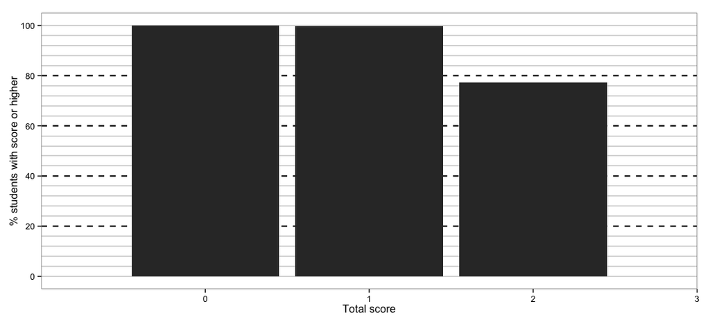

## Category 2

## Percentage Correct

Plot of percentage correct per item. If *more than 70%* of the students answer an item correctly, the students have mastered the material well enough, thus it is coloured *green*. If *less than 40%* of the students answer an item correctly, the students have not mastered the material, and is coloured *red*. *Orange* indicates the percentage correct lies *between 40% and 70%*. The boundaries of the colours are based on multiple choice items with 3 or 4 answer options.

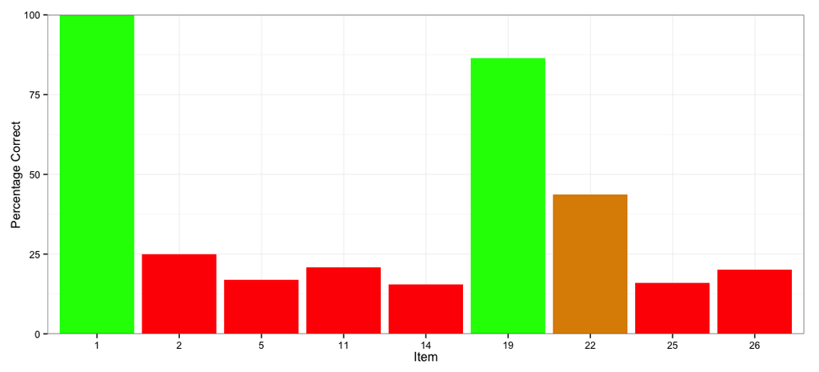

## Item rest correlations

Plot of Item Rest Correlations per item: The correlation between an item (0 for wrong answers and 1 for right answers) and the sum of all other items. Items with a correlation *higher than .05* indicate that students who answered this item correctly answered the other items more often correctly than students who answered this item incorrectly. Thus it is coloured *green*. Items with a correlation *lower than 0* indicate no relationship between this item and the other items, thus it is coloured *red*. *Between 0 and .05*, an item is coloured *orange*.

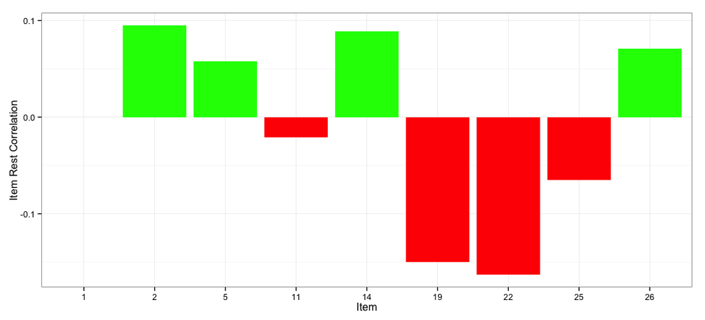

## Percentage chosen per answer options

Percentage plot of all answer options per question. **White** bars represent the **right** answer option(s) and **black** the **wrong** options.

The border represents the performance of an item. The **right** answer options are coloured *green* if *more than 70%* of the students choose this option. In that case, the students have mastered the material. They are coloured *red* if *less than 40%* choose this option. *Between 40% and 70%*, it is coloured *orange*.

The **wrong** answer options are coloured *green* if an option is chosen *10 percentage point less than the right option*. In that case, more students chose the right answer option than the wrong option indicating that students are not confused by the wrong option. They are coloured *red* if an option is chosen *equally or more often than the right option*. In this case, students pick the wrong answer option often, indicating that this option may be right as well. It is coloured *orange* in between these two.

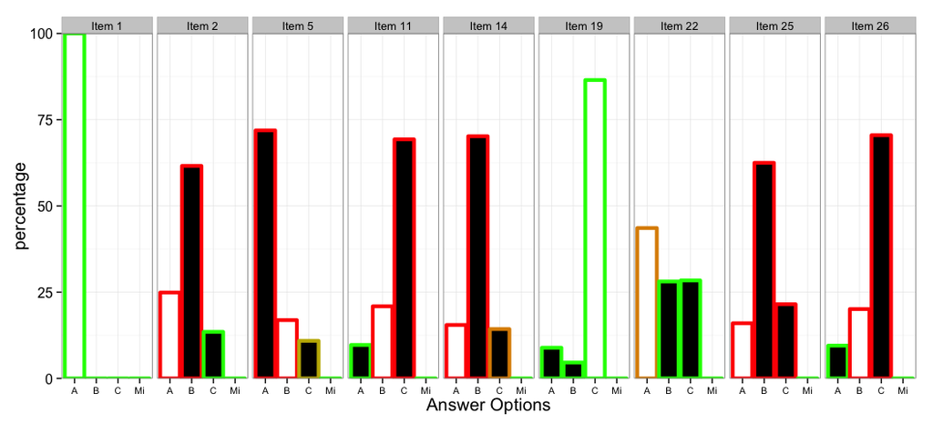

## Item rest correlations per answer option

Item rest correlation (IRC) plot of all answer options per question. The IRC is the correlation between an answer option (1 for students who chose this options and 0 for student who did not) and the sumscore on all other items. **White** bars represent the **right** answer option(s) and **black** the **wrong** options.

The border represents the performance of an item. The **right** answer options are coloured *green* if the IRC is *higher than .05*. In that case, students who picked the right answer option scored higher on all other items than student who did not pick the right option. They are coloured *red* if the IRC is *less than 0*. In that case, students who picked the right answer option scored equally or worse on the other items than students who picked the other options. Between *0 and .05*, the option is coloured *orange*.

The **wrong** answer options are coloured *green* if the IRC is *more than .1 lower than the right option*. In that case, students who answered the other items incorrectly, usually answered this item incorrectly as well. They are coloured *red* if the IRC is *equal or higher than the right answer option*. In that case, students who answered the other items correctly may have answered this item incorrectly. In between these two, the option is coloured *orange*.

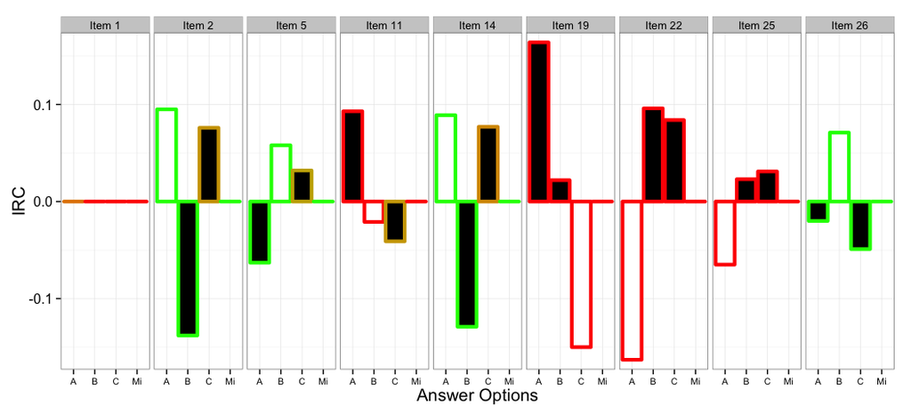

## Cumulative Distribution

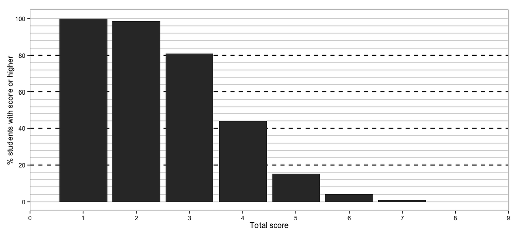

## Category 4

## Percentage Correct

Plot of percentage correct per item. If *more than 70%* of the students answer an item correctly, the students have mastered the material well enough, thus it is coloured *green*. If *less than 40%* of the students answer an item correctly, the students have not mastered the material, and is coloured *red*. *Orange* indicates the percentage correct lies *between 40% and 70%*. The boundaries of the colours are based on multiple choice items with 3 or 4 answer options.

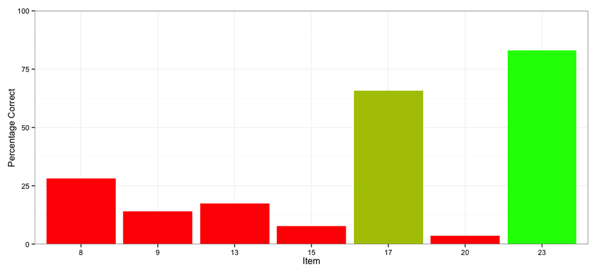

## Item rest correlations

Plot of Item Rest Correlations per item: The correlation between an item (0 for wrong answers and 1 for right answers) and the sum of all other items. Items with a correlation *higher than .05* indicate that students who answered this item correctly answered the other items more often correctly than students who answered this item incorrectly. Thus it is coloured *green*. Items with a correlation *lower than 0* indicate no relationship between this item and the other items, thus it is coloured *red*. *Between 0 and .05*, an item is coloured *orange*.

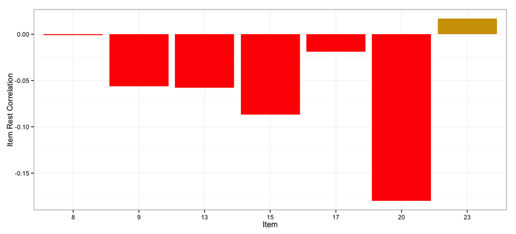

## Percentage chosen per answer options

Percentage plot of all answer options per question. **White** bars represent the **right** answer option(s) and **black** the **wrong** options.

The border represents the performance of an item. The **right** answer options are coloured *green* if *more than 70%* of the students choose this option. In that case, the students have mastered the material. They are coloured *red* if *less than 40%* choose this option. *Between 40% and 70%*, it is coloured *orange*.

The **wrong** answer options are coloured *green* if an option is chosen *10 percentage point less than the right option*. In that case, more students chose the right answer option than the wrong option indicating that students are not confused by the wrong option. They are coloured *red* if an option is chosen *equally or more often than the right option*. In this case, students pick the wrong answer option often, indicating that this option may be right as well. It is coloured *orange* in between these two.

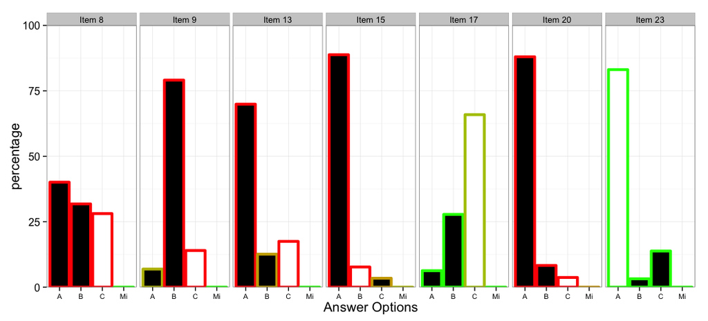

## Item rest correlations per answer option

Item rest correlation (IRC) plot of all answer options per question. The IRC is the correlation between an answer option (1 for students who chose this options and 0 for student who did not) and the sumscore on all other items. **White** bars represent the **right** answer option(s) and **black** the **wrong** options.

The border represents the performance of an item. The **right** answer options are coloured *green* if the IRC is *higher than .05*. In that case, students who picked the right answer option scored higher on all other items than student who did not pick the right option. They are coloured *red* if the IRC is *less than 0*. In that case, students who picked the right answer option scored equally or worse on the other items than students who picked the other options. Between *0 and .05*, the option is coloured *orange*.

The **wrong** answer options are coloured *green* if the IRC is *more than .1 lower than the right option*. In that case, students who answered the other items incorrectly, usually answered this item incorrectly as well. They are coloured *red* if the IRC is *equal or higher than the right answer option*. In that case, students who answered the other items correctly may have answered this item incorrectly. In between these two, the option is coloured *orange*.

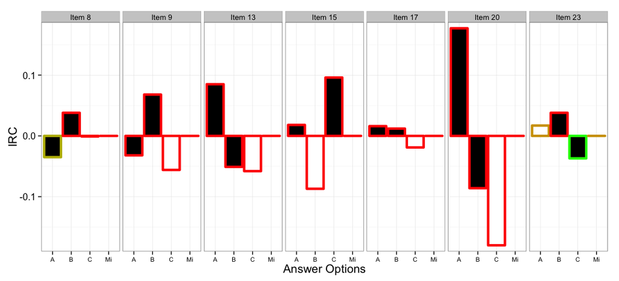

## Cumulative Distribution

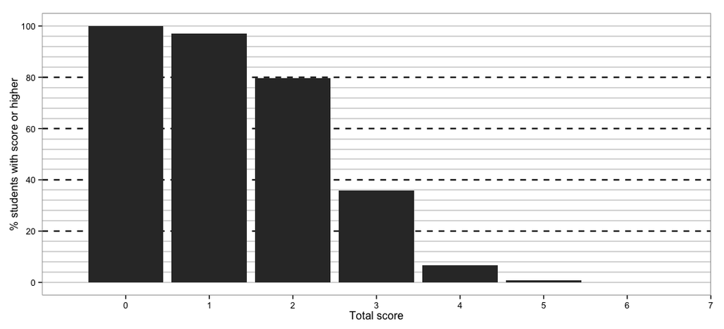

## Category 5

## Percentage Correct

Plot of percentage correct per item. If *more than 70%* of the students answer an item correctly, the students have mastered the material well enough, thus it is coloured *green*. If *less than 40%* of the students answer an item correctly, the students have not mastered the material, and is coloured *red*. *Orange* indicates the percentage correct lies *between 40% and 70%*. The boundaries of the colours are based on multiple choice items with 3 or 4 answer options.

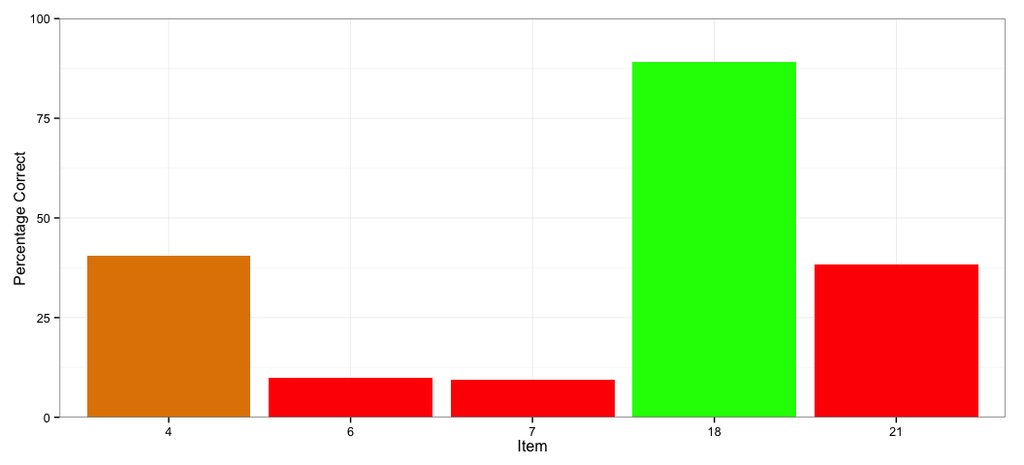

## Item rest correlations

Plot of Item Rest Correlations per item: The correlation between an item (0 for wrong answers and 1 for right answers) and the sum of all other items. Items with a correlation *higher than .05* indicate that students who answered this item correctly answered the other items more often correctly than students who answered this item incorrectly. Thus it is coloured *green*. Items with a correlation *lower than 0* indicate no relationship between this item and the other items, thus it is coloured *red*. *Between 0 and .05*, an item is coloured *orange*.

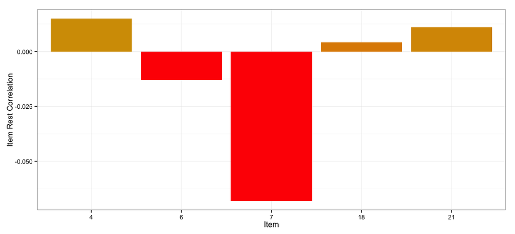

## Percentage chosen per answer options

Percentage plot of all answer options per question. **White** bars represent the **right** answer option(s) and **black** the **wrong** options.

The border represents the performance of an item. The **right** answer options are coloured *green* if *more than 70%* of the students choose this option. In that case, the students have mastered the material. They are coloured *red* if *less than 40%* choose this option. *Between 40% and 70%*, it is coloured *orange*.

The **wrong** answer options are coloured *green* if an option is chosen *10 percentage point less than the right option*. In that case, more students chose the right answer option than the wrong option indicating that students are not confused by the wrong option. They are coloured *red* if an option is chosen *equally or more often than the right option*. In this case, students pick the wrong answer option often, indicating that this option may be right as well. It is coloured *orange* in between these two.

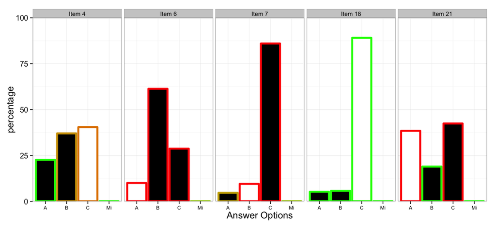

## Item rest correlations per answer option

Item rest correlation (IRC) plot of all answer options per question. The IRC is the correlation between an answer option (1 for students who chose this options and 0 for student who did not) and the sumscore on all other items. **White** bars represent the **right** answer option(s) and **black** the **wrong** options.

The border represents the performance of an item. The **right** answer options are coloured *green* if the IRC is *higher than .05*. In that case, students who picked the right answer option scored higher on all other items than student who did not pick the right option. They are coloured *red* if the IRC is *less than 0*. In that case, students who picked the right answer option scored equally or worse on the other items than students who picked the other options. Between *0 and .05*, the option is coloured *orange*.

The **wrong** answer options are coloured *green* if the IRC is *more than .1 lower than the right option*. In that case, students who answered the other items incorrectly, usually answered this item incorrectly as well. They are coloured *red* if the IRC is *equal or higher than the right answer option*. In that case, students who answered the other items correctly may have answered this item incorrectly. In between these two, the option is coloured *orange*.

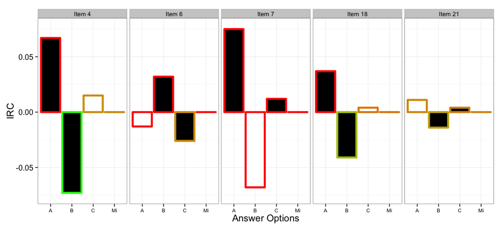

## Cumulative Distribution

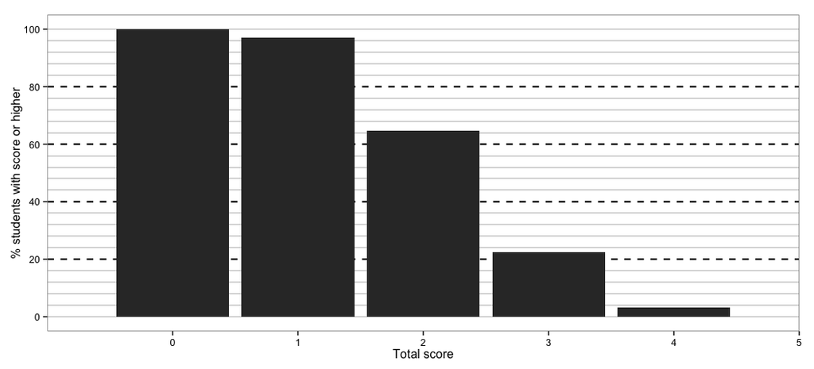